# Analyzing the Addition of Baristas at the Nimitz Coffee Bar

I. M. Wright

SA421 Fall 2017

# Problem statement

The Nimitz Coffee Bar (NCB) cafe has a line where customers wait to place their order with the cashier. Once they have ordered, one or more baristas complete their order. Order completion is conducted on a first-in, first-out (FIFO) basis.

In this report, we analyze the addition of baristas to improve NCB’s customer service. NCB has provided us with data on the arrival times, cashier times, and service times.

# Input data analysis

## Interarrival times

First, we consider the arrival data. To simplify matters, we assumed that any simultaneous arrivals are in fact one second apart.

After inspecting the data visually, we determined that the interarrival times may be appropriately modeled by an exponential, gamma, or lognormal distribution. Using maximum likelihood estimation, the interarrival times best fit

- an exponential distribution with rate 0.0241302,
- a gamma distribution with shape 0.6000929 and rate 0.0144802, and
- a lognormal distribution with mean 2.6943194 and standard deviation 1.7980601.

The histogram of the interarrival time data and the probability density functions of the fitted distributions are shown in the left figure below. In addition, the empirical cumulative distribution function of the interarrival time data and the theoretical cumulative distribution functions of the fitted distributions are shown on the right.

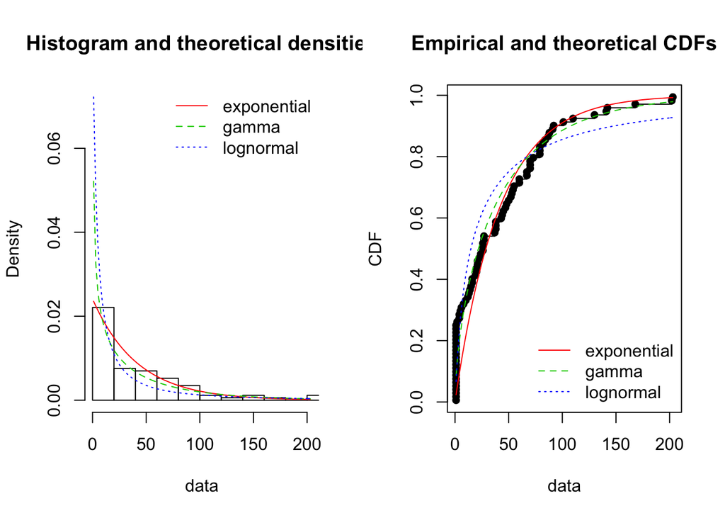

In addition, the goodness-of-fit statistics for these fitted distributions is given in the tables below:

```
## Goodness-of-fit statistics
##                              exponential     gamma lognormal
## Kolmogorov-Smirnov statistic   0.2319726 0.1681478 0.1888069
## Cramer-von Mises statistic     0.6833255 0.3002285 0.7127116
## Anderson-Darling statistic     8.6547846 2.3880547 4.8837440
##
## Goodness-of-fit criteria
##                                exponential    gamma lognormal
## Aikake's Information Criterion    814.5781 798.1295  812.3942
## Bayesian Information Criterion    817.0325 803.0382  817.3029
```

For our simulation study, we chose to model the interarrival times with the distribution with the lowest Bayesian Information Criterion: the gamma distribution with shape 0.6000929 and rate 0.0144802.

### Cashier times

Next, we consider the time each customer spends at the cashier. After inspecting the data visually, we determined that the cashier times may be appropriately modeled by a gamma or lognormal distribution.

Using maximum likelihood estimation, the interarrival times best fit

- a gamma distribution with shape 3.9166559 and rate 0.4638074, and
- a lognormal distribution with mean 2.0005 and standard deviation 0.4792557.

The histogram of the cashier time data and the probability density functions of the fitted distributions are shown on the left figure below. In addition, the empirical cumulative distribution function of the cashier time data and the theoretical cumulative distribution functions of the fitted distributions are shown on the right.

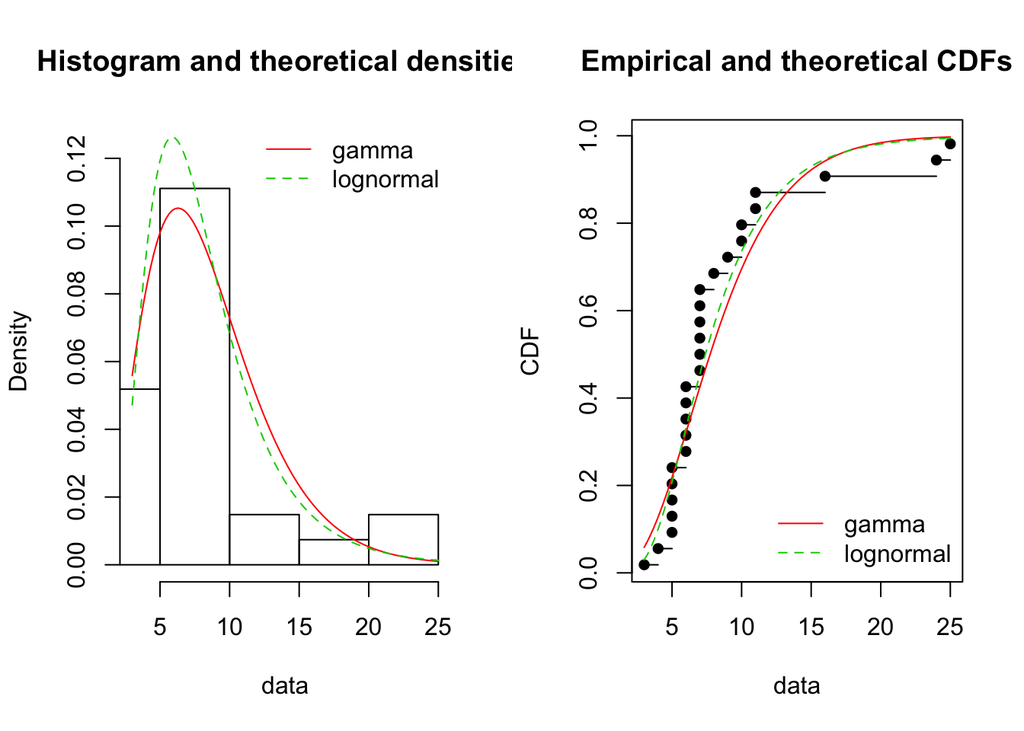

In addition, the goodness-of-fit statistics for these fitted distributions is given in the tables below:

```
## Goodness-of-fit statistics
##                                  gamma lognormal
## Kolmogorov-Smirnov statistic 0.2413276 0.2120103
## Cramer-von Mises statistic   0.2531593 0.1613930
## Anderson-Darling statistic   1.4865258 0.9588523
##
## Goodness-of-fit criteria
##                                   gamma lognormal
## Aikake's Information Criterion 154.0660  148.9316
## Bayesian Information Criterion 156.6577  151.5232
```

### Service times

Finally, we analyze the time it takes to serve each customer. After inspecting the data visually, we determined that the service times may be appropriately modeled by a gamma or lognormal distribution.

Using maximum likelihood estimation, the interarrival times best fit

- a gamma distribution with shape 2.6522086 and rate 0.0205593, and
- a lognormal distribution with mean 4.6595188 and standard deviation 0.737438.

The histogram of the service time data and the probability density functions of the fitted distributions are shown on the left figure below. In addition, the empirical cumulative distribution function of the service time data and the theoretical cumulative distribution functions of the fitted distributions are shown on the right.

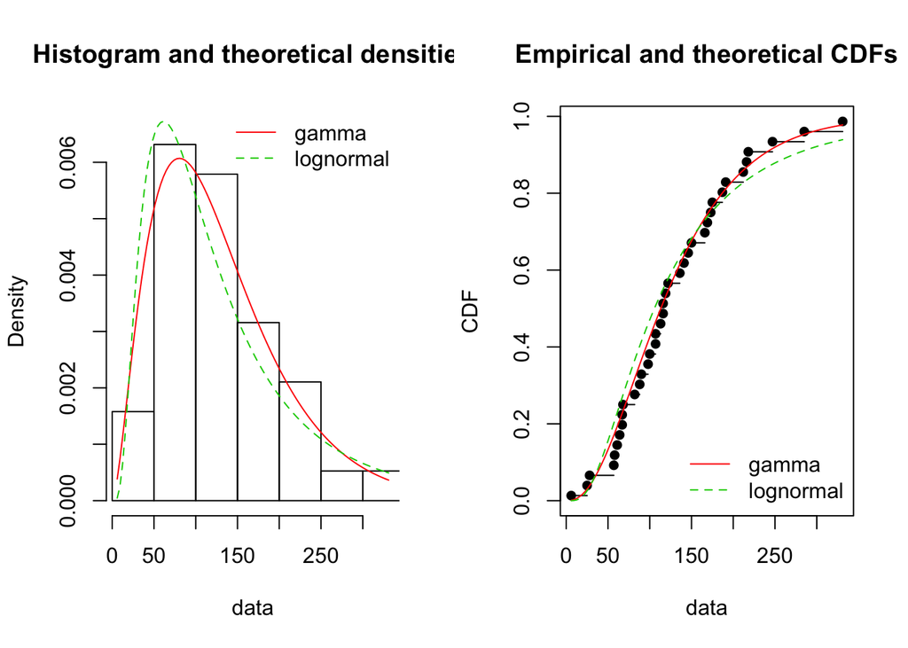

In addition, the goodness-of-fit statistics for these fitted distributions is given in the tables below:

```
## Goodness-of-fit statistics
##                                   gamma lognormal
## Kolmogorov-Smirnov statistic 0.09107123 0.1226418
## Cramer-von Mises statistic   0.04132694 0.1394110
## Anderson-Darling statistic   0.31873552 0.9717473
##
## Goodness-of-fit criteria
##                                   gamma lognormal
## Aikake's Information Criterion 433.6476  442.8152
## Bayesian Information Criterion 436.9228  446.0904
```

For our simulation study, we chose to model the service times with the distribution with the lowest Bayesian Information Criterion: the gamma distribution with shape 2.6522086 and rate 0.0205593.

# Simulation model and scenarios

We modeled the NCB in JaamSim. A graphical representation of the simulation model is shown below.

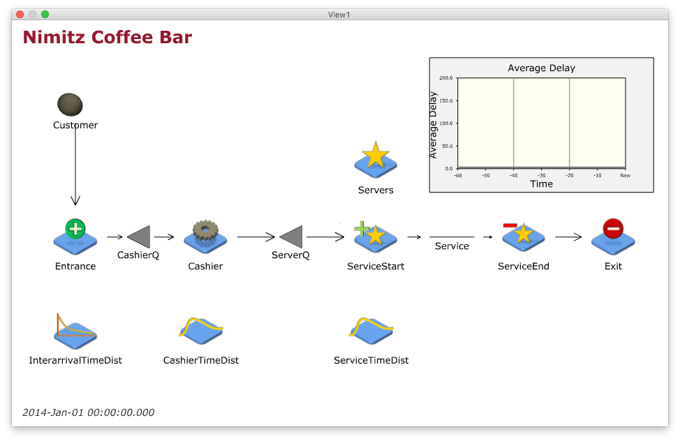

Simulation Flowchart

We examined the impact on average delay when NCB has 1, 2, 3, and 4 baristas. For each of these numbers of baristas, we ran our simulation 100 times.

# Simulation output analysis

## Impact of number of baristas

| Number of baristas | Average delay | CI range |
| --- | --- | --- |
| 1 | 2351.123913 | 270.3521511 |
| 2 | 18.155362 | 1.9748864 |
| 3 | 2.643241 | 0.3393850 |
| 4 | 0.466200 | 0.0957485 |

# Conclusion